# Final Project RFS

Jerome Goh

2024-03-19

## Data Cleaning Plan

> Re-factor qualitative variables, namely: - Drive System Code - Tested Transmission Type - Fuel Type Cd - Test Procedure Cd

> Tackle FE measured by MPG FE DOES DEPEND ON THE TYPE OF TESTING. GAS EMISSIONS ALSO DIFFER BASED ON TYPE OF TESTING

OR

Load workspace image titled “impute.RData”, to view all generated variables in global environment

## Data Cleaning

```
##  [1] "Vehicle.Manufacturer.Name"     "Represented.Test.Veh.Model"
##  [3] "Test.Veh.Displacement..L."     "Vehicle.Type"
##  [5] "Rated.Horsepower"              "X..of.Cylinders.and.Rotors"
##  [7] "trans"                         "X..of.Gears"
##  [9] "trans.lockup"                  "drive.sys"
## [11] "trans.overdrive"               "Equivalent.Test.Weight..lbs.."
## [13] "Axle.Ratio"                    "N.V.Ratio"
## [15] "Test.Originator"               "test.procedure"
## [17] "fuel.type"                     "test.category"
## [19] "THC"                           "CO"
## [21] "CO2"                           "NOx"
## [23] "PM"                            "CH4"
## [25] "N2O"                           "RND_ADJ_FE"
## [27] "FE_UNIT"                       "DT.Inertia.Work.Ratio.Rating"
## [29] "DT.Absolute.Speed.Change.Ratg" "DT.Energy.Economy.Rating"
## [31] "Target.Coef.A..lbf."           "Target.Coef.B..lbf.mph."
## [33] "Target.Coef.C..lbf.mph..2."    "Set.Coef.A..lbf."
## [35] "Set.Coef.B..lbf.mph."          "Set.Coef.C..lbf.mph..2."
## [37] "aftertreatment"                "Averging.Method.Desc"
```

Since EVs do not produce emissions, we set their emissions from N/A to 0

```r
# Set gas = 0 for EV
car_test$THC <- ifelse(is.na(car_test$THC) & car_test$fuel.type == "Electricity", 0, car_test$THC)
car_test$CO <- ifelse(is.na(car_test$CO) & car_test$fuel.type == "Electricity", 0, car_test$CO)
car_test$CO2 <- ifelse(is.na(car_test$CO2) & car_test$fuel.type == "Electricity" , 0, car_test$CO2)
car_test$NOx <- ifelse(is.na(car_test$NOx) & car_test$fuel.type == "Electricity" , 0, car_test$NOx)
car_test$PM <- ifelse(is.na(car_test$PM) & car_test$fuel.type == "Electricity" , 0, car_test$PM)
car_test$CH4 <- ifelse(is.na(car_test$CH4) & car_test$fuel.type == "Electricity" , 0, car_test$CH4)
car_test$N2O <- ifelse(is.na(car_test$N2O) & car_test$fuel.type == "Electricity", 0, car_test$N2O)

EV <- car_test[car_test$fuel.type=="Electricity", ] # check if gas variables set

# Set gas = 0 for HF
car_test$THC <- ifelse(is.na(car_test$THC) & car_test$fuel.type == "Hydrogen 5", 0, car_test$THC)
car_test$CO <- ifelse(is.na(car_test$CO) & car_test$fuel.type == "Hydrogen 5", 0, car_test$CO)
car_test$CO2 <- ifelse(is.na(car_test$CO2) & car_test$fuel.type == "Hydrogen 5" , 0, car_test$CO2)
car_test$NOx <- ifelse(is.na(car_test$NOx) & car_test$fuel.type == "Hydrogen 5" , 0, car_test$NOx)
car_test$PM <- ifelse(is.na(car_test$PM) & car_test$fuel.type == "Hydrogen 5" , 0, car_test$PM)
car_test$CH4 <- ifelse(is.na(car_test$CH4) & car_test$fuel.type == "Hydrogen 5" , 0, car_test$CH4)
car_test$N2O <- ifelse(is.na(car_test$N2O) & car_test$fuel.type == "Hydrogen 5", 0, car_test$N2O)

HF <- car_test[car_test$fuel.type=="Hydrogen 5", ] # check if gas variables set
```

For ease of analysis, we first partition into numeric and categorical variables. Then visualize the missingness separately.

```r
library(dplyr)
car_test <- car_test %>% filter (!is.na(car_test$Vehicle.Manufacturer.Name))

# Split numeric and categorical components
numeric.car_test <- car_test %>% select_if(is.numeric)

numeric_variables <- sapply(car_test, is.numeric)
cat.car_test <- car_test[!numeric_variables]

# Install package "finalfit"

library(finalfit) # library for identifying and handling missing data
```

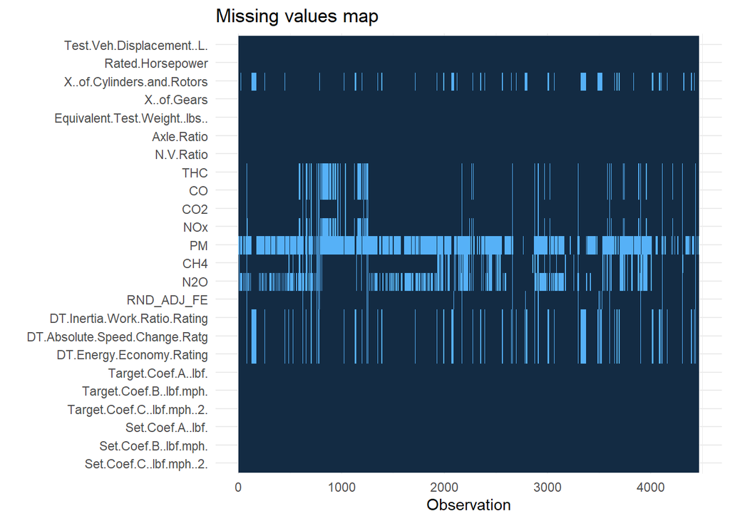

```r
numeric.car_test %>%
    missing_plot() # Visualize the scope of missingness of numeric
```

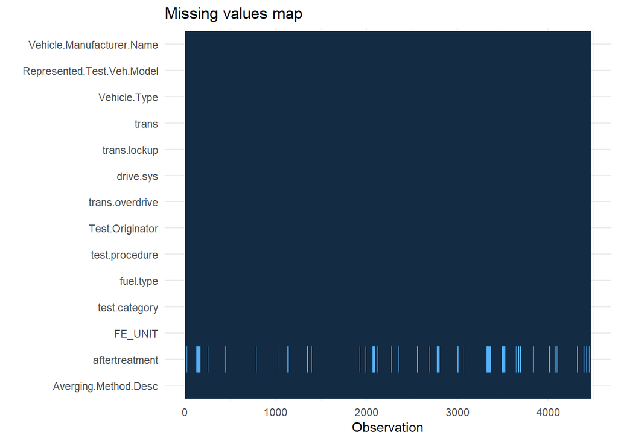

```r
# Among the gases, N20 and CH4 are weird, though PM is justified
# PM may be MNAR

cat.car_test %>%
    missing_plot() # Scope of missingness of categorical
```

```r
table(car_test$Aftertreatment.Device.Cd)
```

```
## < table of extent 0 >
```

```r
table(car_test$aftertreatment)
```

```
##
##     Diesel Particulate Filter                         Other
##                            34                            47
##            Oxidation catalyst Selective Catalytic Reduction
##                            40                            40
##            Three-way catalyst
##                          3870
```

### (Misc.) Analysis of Fuel Economy

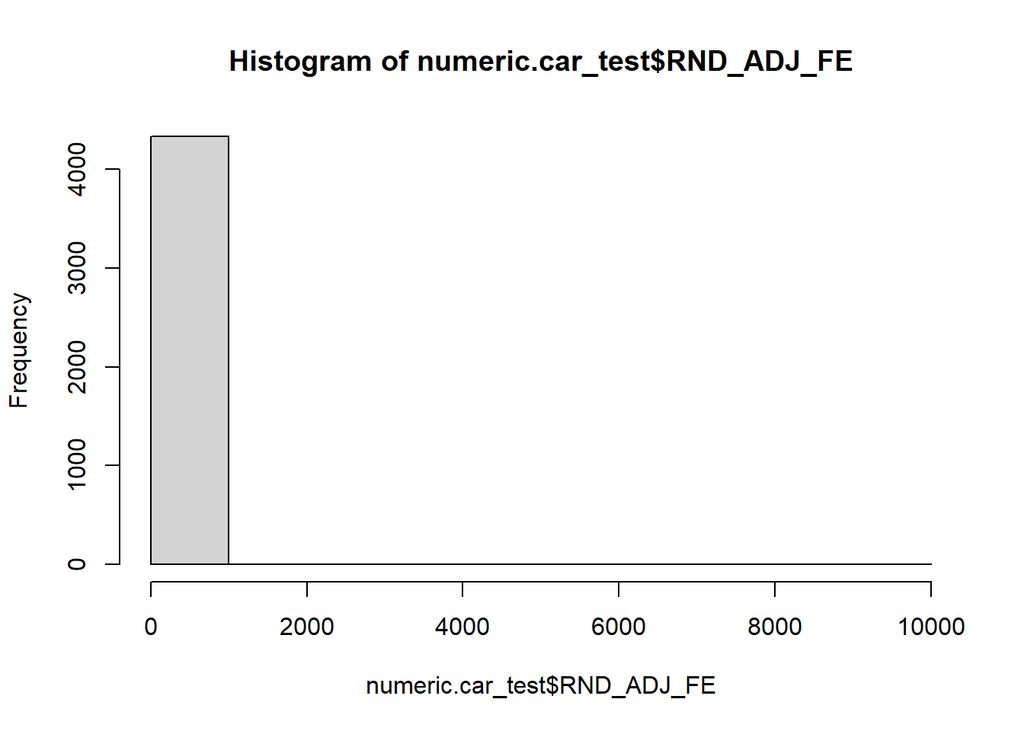

```r
# Inspect response variable
hist(numeric.car_test$RND_ADJ_FE)
```

```r
summary(numeric.car_test$RND_ADJ_FE)
```

```
##     Min.  1st Qu.   Median     Mean  3rd Qu.     Max.     NA's
##     4.50    23.57    30.80    47.31    41.90 10000.00      131
```

```r
# There is an observation of 10,000 MPG. Let's isolate it
out <- car_test[car_test$RND_ADJ_FE > 50, ]


car_test <- car_test[car_test$RND_ADJ_FE < 200, ]
# the observations with FE > 200, being high consumption gas cars, does not make sense.
```

## Missing Data Analysis

### Missingness, grouped by fuel type CD

- 19: Federal Cert Diesel 7-15 PPM Sulfur
- 26: Cold CO Regular (Tier 2)
- 27: Cold CO Premium (Tier 2)
- 38: E85 (85% Ethanol 15% EPA Unleaded Gasoline)
- 39: Tier 3 E10 Regular Gasoline (9 RVP @Low Alt.)
- 50: Hydrogen 5 *(non-gas)*
- 61: Tier 2 Cert Gasoline
- 62: Electricity *(non-gas)*

> For Test Fuel Type CD == 62, set gas values to 0

Missingness between fuel type and gas

```r
library(naniar) # another missingdata viz library
# Dataframe with fuel type code and each gas emission variable
fuel_gas <- data.frame(car_test$fuel.type, car_test$CO, car_test$CO2, car_test$THC, car_test$N2O, car_test$CH4, car_test$NOx, car_test$PM)
colnames(fuel_gas)[1] <- "fuel.type" #rename fuel type
fg.mat <- fuel_gas %>% group_by(fuel.type) %>% miss_var_summary() #matrix of missing gases, grouped by fuel type

table(fuel_gas$fuel.type) # about 81.9% are Tier 2 Gas
```

```
##
##                      Cold CO Premium (Tier 2)
##                                            75
##                      Cold CO Regular (Tier 2)
##                                           139
##   E85 (85% Ethanol 15% EPA Unleaded Gasoline)
##                                            54
##                                   Electricity
##                                           380
##           Federal Cert Diesel 7-15 PPM Sulfur
##                                           120
##                                    Hydrogen 5
##                                            10
##                          Tier 2 Cert Gasoline
##                                          3553
## Tier 3 E10 Premium Gasoline (9 RVP @Low Alt.)
##                                             0
## Tier 3 E10 Regular Gasoline (9 RVP @Low Alt.)
##                                             0
```

We want an impression of what cars utilize fuel types besides Type 2 Gas

```r
coldco_veh <- car_test %>%
    filter(fuel.type %in% c("Cold CO Premium (Tier 2)","Cold CO Regular (Tier 2)"))
```

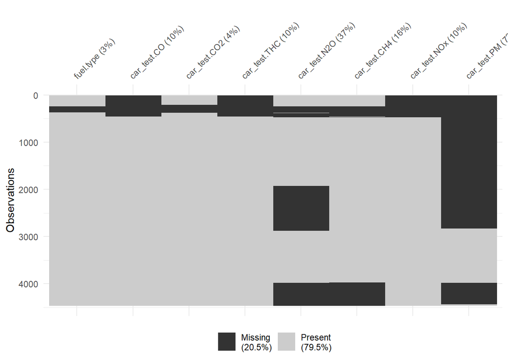

```r
vis_miss(fuel_gas, cluster = TRUE) # Pattern might be because of EV. We set equal 0 for EV.
```

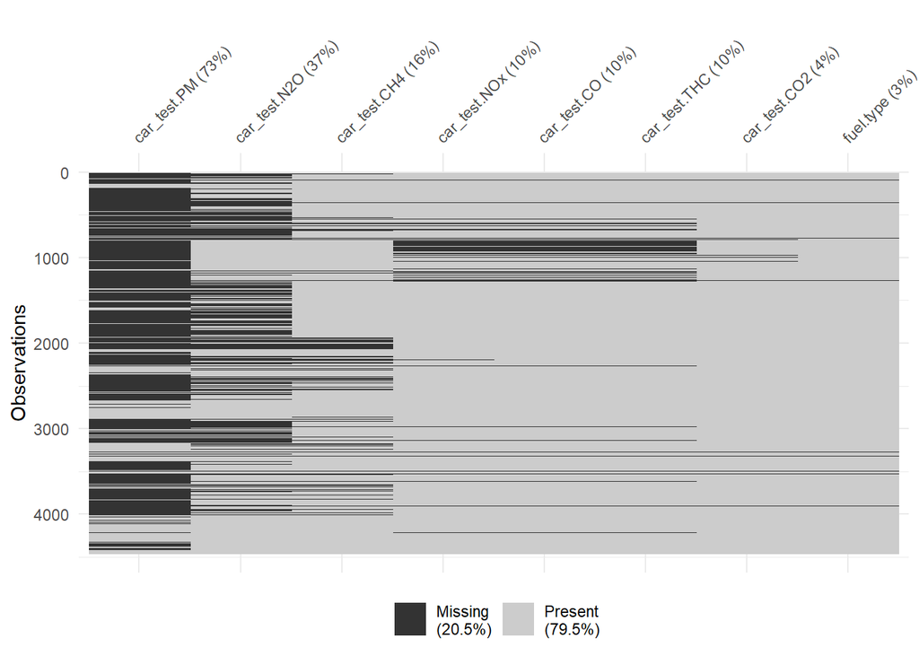

```r
vis_miss(fuel_gas, sort_miss = TRUE) # in descending order
```

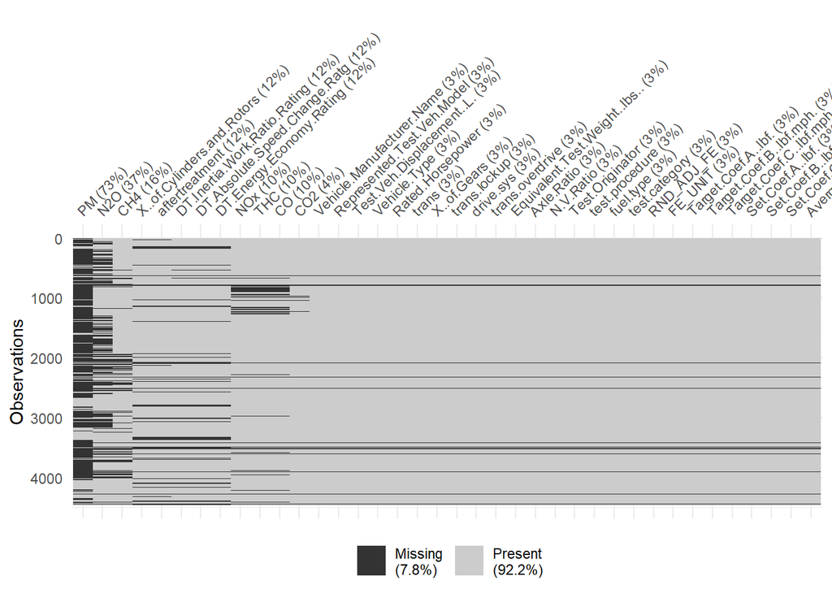

```r
vis_miss(car_test, sort_miss = TRUE)
```